# ▶ RTB win-selection-bias debiasing → bidding — a runnable demo

**What this shows, end-to-end, in ~1 minute (CPU only, no 25G data, no GPU):**

1. **Real usage** — a live RTB micro-pipeline: a market-calibrated testbed → a **biased** vs **debiased** click model → a **bid** (`bid = p̂·CPC`) → an **auction** → business metrics (surplus, win-rate, unprofitable-win share, ROI). The *same decision* is also run through the production auction simulator.
2. **The recalibration trap** — naively recalibrating the biased model **over-bids** and *loses* money.
3. **Bid shading** — a practical lever, with its honest caveat.
4. **The findings** — the phase diagram (C1) and the neural anchor (real ESCM²-WC: the censoring-bug fix and the calibration 2×2), loaded verbatim from the committed witness JSONs.

> **Why a semi-synthetic testbed?** Decision value (did debiasing change the *bid* for the better?) is *unmeasurable* on real iPinYou — flat-bid logging censors the lost inventory. So we use **real iPinYou market statistics** + a controllable ground-truth pCTR with **observable lost inventory**. Every number here is reproducible from `requirements.txt`; neural results load from JSON (see `repro/check.py`).

```python
import sys, json, warnings
from pathlib import Path
import numpy as np, pandas as pd
import matplotlib.pyplot as plt
from lightgbm import LGBMClassifier
from sklearn.isotonic import IsotonicRegression
warnings.filterwarnings("ignore")
pd.set_option("display.float_format", lambda v: f"{v:,.3f}")

ROOT = Path.cwd()
for _ in range(4):
    if (ROOT / "witnesses").exists(): break
    ROOT = ROOT.parent
sys.path.insert(0, str(ROOT / "witnesses"))   # phase_diagram / recal_trap (numpy/sklearn/lgb; no jax)
sys.path.insert(0, str(ROOT / "old"))          # production auction simulator (numpy/pandas; no jax)
import phase_diagram as P
import recal_trap as R
from src.bidding.simulator import run_auction_simulation, compute_simulation_metrics
CPC = P.CPC

load = lambda n: json.load(open(ROOT / "witnesses" / n))
phase, recal, neural = load("phase_diagram.json"), load("recal_trap.json"), load("neural_anchor.json")
mkt = json.load(open(ROOT / "old/results/market_price_cdf/summary.json"))["market_price_stats"]
print(f"loaded witnesses + JSONs  |  CPC={CPC:.0f}  |  real iPinYou market median={mkt['median']:.0f} CPM")
```

```
loaded witnesses + JSONs  |  CPC=3000  |  real iPinYou market median=68 CPM
```

## 1. The market and the funnel

A bid passes **Bid → Win → Click**: you only observe a click on impressions you **won**. So a click model trained on winners is **selection-biased**, and biased pCTR → biased bids. The testbed's market price is a lognormal **calibrated to the real iPinYou price distribution** below (median ≈ 68 CPM).

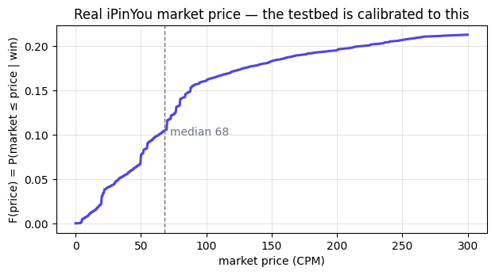

```
real market: mean 78, median 68, floor-binding 21%
```

```python
cdf = np.load(ROOT / "old/results/market_price_cdf/km_cdf_overall.npz")
grid, F = cdf["price_grid"], cdf["cdf"]
m = grid <= 300
fig, ax = plt.subplots(figsize=(7, 3.4))
ax.plot(grid[m], F[m], color="#4F46E5", lw=2.2)
ax.axvline(mkt["median"], ls="--", color="#6B7280", lw=1)
ax.text(mkt["median"] + 4, 0.1, f"median {mkt['median']:.0f}", color="#6B7280")
ax.set_xlabel("market price (CPM)"); ax.set_ylabel("F(price) = P(market ≤ price | win)")
ax.set_title("Real iPinYou market price — the testbed is calibrated to this")
ax.grid(alpha=.3); plt.show()
print(f"real market: mean {mkt['mean']:.0f}, median {mkt['median']:.0f}, floor-binding {mkt['floor_binding_rate']:.0%}")
```

## 2. A live RTB micro-pipeline (real usage)

Generate one market with **ground-truth pCTR** and **observable lost inventory**, fit a **biased** (winners-only) and an **IPW-debiased** click model *at the same capacity*, bid truthfully (`bid = p̂·CPC`), and read off the decision metrics vs the **oracle** (true pCTR). Strong selection (γ=1.2), linear model.

```python
def make_world(gamma=1.2, theta=0, seed=0):
    """Real-market-calibrated testbed: ground-truth pCTR + observable lost inventory + a win-propensity model."""
    X, pctr, click, mprice = P.make_pop(gamma, theta, seed)
    b0 = np.quantile(mprice, 0.5)
    win = (b0 >= mprice).astype(int)                 # which bids won (flat bid at the market median)
    pwin = LGBMClassifier(n_estimators=150, num_leaves=31, min_child_samples=80,
                          verbose=-1).fit(X, win).predict_proba(X)[:, 1]   # P(win | x)
    return X, pctr, click, mprice, win, pwin

X, pctr, click, mprice, win, pwin = make_world(gamma=1.2, seed=0)
CAP = "linear"
p_oracle = pctr
p_biased = P.fit_pred(X, win, click, CAP, False, pwin)   # winners-only → selection-biased
p_debias = P.fit_pred(X, win, click, CAP, True,  pwin)   # winners + IPW(1/P(win)) → debiased

def decision_metrics(name, phat):
    d = R.decompose(phat, pctr, mprice)                  # truthful bid = phat·CPC, 2nd-price surplus
    return {"model": name, "mean_bid": d["mean_bid"], "win_rate": d["n_wins"] / len(pctr),
            "unprofitable_win_share": d["unprofitable_win_share"], "won_surplus_$M": d["won_surplus"] / 1e6}

print(f"win rate {win.mean():.2f} | true pCTR mean {pctr.mean():.3f} | "
      f"biased pCTR mean {p_biased.mean():.3f} (collapsed by selection) | debiased mean {p_debias.mean():.3f}")
pd.DataFrame([decision_metrics("oracle (true pCTR)", p_oracle),
              decision_metrics("biased (winners-only)", p_biased),
              decision_metrics("debiased (IPW)", p_debias)])
```

```
win rate 0.50 | true pCTR mean 0.056 | biased pCTR mean 0.052 (collapsed by selection) | debiased mean 0.055
```

|  | model | mean_bid | win_rate | unprofitable_win_share | won_surplus_$M |
| --- | --- | --- | --- | --- | --- |
| 0 | oracle (true pCTR) | 168.800 | 0.417 | 0.000 | 9.589 |
| 1 | biased (winners-only) | 154.600 | 0.716 | 0.499 | 4.385 |
| 2 | debiased (IPW) | 165.100 | 0.752 | 0.496 | 5.788 |

The biased model's pCTR **collapses** (selection makes winners low-pCTR), so it under-bids and captures little surplus; **IPW debiasing recovers it and wins more profitable inventory**. Now the *same three bid vectors* through the **production auction simulator** (`old/src/bidding/simulator.py`, 2nd-price):

```python
def production_sim(name, phat):
    bids, values = phat * CPC, pctr * CPC
    res = run_auction_simulation(bids=bids, market_prices=mprice, values=values, clicks=click,
                                 auction_type="second_price")
    mt = compute_simulation_metrics(res, values=values, market_prices=mprice, strategy_name=name, cpc_target=CPC)
    return {"strategy": name, "win_rate": mt.win_rate, "total_surplus_$M": mt.total_surplus / 1e6,
            "overpayment_ratio": mt.overpayment_ratio, "ROI": mt.roi}

pd.DataFrame([production_sim("biased", p_biased), production_sim("debiased (IPW)", p_debias),
              production_sim("oracle", p_oracle)])
```

|  | strategy | win_rate | total_surplus_$M | overpayment_ratio | ROI |
| --- | --- | --- | --- | --- | --- |
| 0 | biased | 0.716 | 4.385 | 1.964 | 1.754 |
| 1 | debiased (IPW) | 0.752 | 5.788 | 1.821 | 1.870 |
| 2 | oracle | 0.417 | 9.589 | 4.250 | 2.993 |

## 3. The recalibration trap (live)

A tempting fix for the biased model: just **recalibrate** it (isotonic on winners). Watch what it does to the bid and the surplus.

```python
p_recal = P.xfit_isotonic(p_biased[win == 1], click[win == 1], p_biased)   # naive recalibration of the biased model
print("Recalibration raises the level → inflates the bid → wins more UNPROFITABLE inventory → surplus DROPS:")
trap = pd.DataFrame([decision_metrics("biased", p_biased),
                     decision_metrics("biased + naive recal", p_recal),
                     decision_metrics("debiased (IPW)", p_debias)])
rs, rb = recal["cases"]["linear_strong"], recal["robustness"]
print(f"canonical (recal_trap.json): biased {rs['biased']['won_surplus']/1e6:.2f}M → "
      f"+recal {rs['biased_recal']['won_surplus']/1e6:.2f}M (↓) → +IPW {rs['debiased']['won_surplus']/1e6:.2f}M; "
      f"recal inflates the bid +{rb['recal_bid_inflation_pp']:.0f}% — and it holds in {rb['recal_lowers_surplus_frac']} seeds.")
trap
```

```
Recalibration raises the level → inflates the bid → wins more UNPROFITABLE inventory → surplus DROPS:
canonical (recal_trap.json): biased 4.31M → +recal 3.26M (↓) → +IPW 5.92M; recal inflates the bid +43% — and it holds in 5/5 seeds.
```

|  | model | mean_bid | win_rate | unprofitable_win_share | won_surplus_$M |
| --- | --- | --- | --- | --- | --- |
| 0 | biased | 154.600 | 0.716 | 0.499 | 4.385 |
| 1 | biased + naive recal | 191.200 | 0.736 | 0.509 | 3.742 |
| 2 | debiased (IPW) | 165.100 | 0.752 | 0.496 | 5.788 |

## 4. Bid shading (a practical lever)

Real bidders rarely bid `p̂·CPC` verbatim — they apply **linear shading** `bid = α·p̂·CPC`. Best-case shading finds the α that maximizes surplus. **Honest caveat:** optimal shading *rewards spread*, so report it *alongside* truthful bidding, never instead (it can flatter a miscalibrated model — see §5).

```python
ALPHAS = np.concatenate([np.linspace(0.05, 1.0, 20), np.linspace(1.1, 4.0, 30)])
best_shaded = lambda phat: max(P.surplus(phat, pctr, mprice, alpha=a) for a in ALPHAS)
s_or = P.surplus(pctr, pctr, mprice)
for name, phat in [("biased", p_biased), ("debiased (IPW)", p_debias)]:
    t, sh = P.surplus(phat, pctr, mprice), best_shaded(phat)
    print(f"{name:16}  truthful {t/1e6:5.2f}M   best-shaded {sh/1e6:5.2f}M   (oracle {s_or/1e6:.2f}M)")
```

```
biased            truthful  4.38M   best-shaded  4.41M   (oracle 9.59M)
debiased (IPW)    truthful  5.79M   best-shaded  5.79M   (oracle 9.59M)
```

## 5. The findings — neural anchor (real iPinYou features + the real ESCM²-WC)

Loaded verbatim from `witnesses/neural_anchor.json` (the heavy GPU training is *not* re-run here). Two honest, hard-won results — each a **self-correction** caught by adversarial review:

- **The "over-bidding" was a data-contract bug.** A first pass showed the neural debiaser over-bidding (truthful edge −47pp). It was mostly a *censoring wiring bug* (the loss expects click censored to 0 on losses). **Fixed (`click·win`) → the real ESCM²-WC genuinely helps truthful bidding (+7.2pp).**
- **A calibration 2×2** — does *selection-aware* IPW calibration beat naive? **Only at weak selection (good overlap)**; it loses at strong selection (low ESS). Net, naive ties it. **Lesson: calibration *accuracy* ≠ bidding *value*** (a level-correct calibration over-bids near the margin).

```python
ns = neural["summary"]
print(f"censoring fix:  truthful edge {ns['frozen_prefix_truthful_edge_neural_pp']:+.0f}pp (uncensored bug)"
      f"  →  +{ns['truthful_edge_neural_pp']:.1f}pp (censored fix)  [LR {ns['truthful_edge_linear_pp']:+.1f}, "
      f"LGB {ns['truthful_edge_gbm_pp']:+.1f} — only the neural debiaser helps]")
print(f"calibration:    +IPW {ns['truthful_edge_neural_ipwcal_pp']:+.1f}  ≈  +naive {ns['truthful_edge_neural_naivecal_pp']:+.1f}pp")
print(f"2x2 (IPW − naive on the biased model, by γ): {ns['bias_ipw_minus_naive_by_gamma']}  "
      f"→ IPW wins ONLY at weak selection (good ESS); accuracy ≠ bidding value")
print(f"caveat: {neural['_meta']['caveat']}")
```

```
censoring fix:  truthful edge -47pp (uncensored bug)  →  +7.2pp (censored fix)  [LR -4.8, LGB -1.6 — only the neural debiaser helps]
calibration:    +IPW +11.1  ≈  +naive +11.2pp
2x2 (IPW − naive on the biased model, by γ): {'0.4': 1.24, '0.8': -0.23, '1.2': -6.38}  → IPW wins ONLY at weak selection (good ESS); accuracy ≠ bidding value
caveat: n=2 neural seeds/γ AND the p* LightGBM fit is mildly non-deterministic (~±0.3pp run-to-run); trust the SIGN/DIRECTION of the neural results, not the exact magnitudes. repro asserts robust flags only.
```

**The mechanism, live (and why it's regime-dependent):** both calibrators shift the *level*; *which* lands closer to truth depends on the regime (overlap/ESS, model). On the real-feature neural 2×2 above, IPW lifts more than naive; on this Gaussian cell it can be the reverse. The robust point isn't "which calibrator is more accurate" — it's that a **level shift drives the bid**, so a level-accurate calibration is **not** reliably a better *bidding* one near the 2nd-price margin (**accuracy ≠ bidding value**).

```python
def calibrate_ipw(p, click, win, pwin):
    w = win == 1
    sw = 1.0 / np.clip(pwin[w], 0.05, 1.0); sw = sw / sw.mean()
    return IsotonicRegression(out_of_bounds="clip").fit(p[w], click[w], sample_weight=sw).transform(p)

p_naive = P.xfit_isotonic(p_biased[win == 1], click[win == 1], p_biased)
p_ipw   = calibrate_ipw(p_biased, click, win, pwin)
print(f"biased pCTR mean {p_biased.mean():.3f}  |  +naive-cal {p_naive.mean():.3f}  |  "
      f"+IPW-cal {p_ipw.mean():.3f}  |  true {pctr.mean():.3f}")
print("→ both calibrators move the LEVEL (here naive overshoots, IPW lands near true — the direction is "
      "regime-\n  dependent; the neural 2x2 above shows the opposite). What's robust: a level shift drives "
      "the bid, so\n  a more level-accurate calibration is NOT reliably a better *bidding* one — accuracy ≠ bidding value.")
```

```
biased pCTR mean 0.052  |  +naive-cal 0.064  |  +IPW-cal 0.057  |  true 0.056
→ both calibrators move the LEVEL (here naive overshoots, IPW lands near true — the direction is regime-
  dependent; the neural 2x2 above shows the opposite). What's robust: a level shift drives the bid, so
  a more level-accurate calibration is NOT reliably a better *bidding* one — accuracy ≠ bidding value.
```

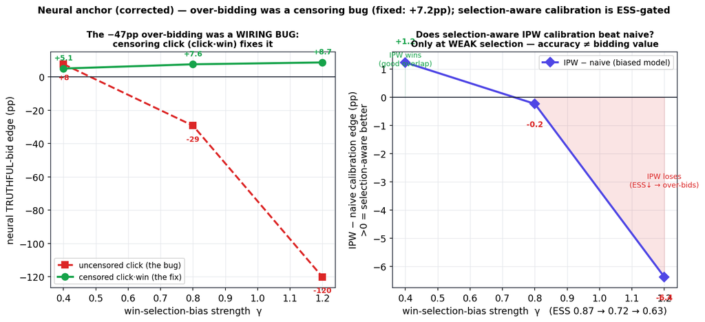

```python
from IPython.display import Image
Image(filename=str(ROOT / "witnesses/figures/fig_neural_anchor.png"))
```

## 6. The findings — the phase diagram (C1)

Within a fixed model class, IPW debiasing helps a **weak** model (growing with selection) but **not a strong** one; the large apparent edge over a different-capacity baseline is **model capacity, not debiasing** (reported separately). This reproduces the *sign* of the real iPinYou result (robust vs LR, not vs LGB, I²=0.82). From `witnesses/phase_diagram.json`.

```
within-capacity IPW debiasing edge:  linear +4.4pp  |  gbm -1.9pp
by selection strength γ (linear): {'0.4': -0.84, '0.8': 5.03, '1.2': 8.91}  (grows with selection: True)
capacity gap (a GBM beats an LR — NOT debiasing): +26.3pp (reported separately)
```

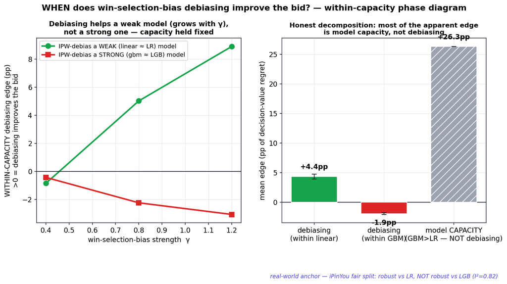

```python
ps = phase["summary"]
print(f"within-capacity IPW debiasing edge:  linear +{ps['debias_edge_ipw_within_linear_pp']:.1f}pp  |  "
      f"gbm {ps['debias_edge_ipw_within_gbm_pp']:+.1f}pp")
print(f"by selection strength γ (linear): {ps['debias_edge_ipw_within_linear_by_gamma']}  "
      f"(grows with selection: {ps['grows_with_selection']})")
print(f"capacity gap (a GBM beats an LR — NOT debiasing): +{ps['capacity_gap_pp']:.1f}pp (reported separately)")
Image(filename=str(ROOT / "witnesses/figures/fig_phase_diagram.png"))
```

## 7. Takeaways

- **Real usage:** win-selection bias collapses a winners-only click model → it under-bids; IPW debiasing recovers it and wins more profitable inventory (live, above). The production auction simulator agrees.
- **Recalibration trap:** naively recalibrating a biased model *over-bids* into unprofitable inventory and **lowers** surplus — a real, robust failure mode of the obvious fix.
- **Calibration accuracy ≠ bidding value:** even the *principled* selection-aware (IPW) calibration only pays when overlap is good; near the 2nd-price margin a level-correct calibration over-bids. For truthful bidding, conservative under-calibration is safer.
- **On real iPinYou features + the real ESCM²-WC:** correctly wired, debiasing genuinely helps truthful bidding (+7.2pp) — the earlier "−47pp" was a data-contract bug, not the method.

**Honest scope.** Semi-synthetic (real market + features, synthesized selection; ground-truth pCTR is a fitted surrogate); decision value is unmeasurable on real iPinYou (the data ceiling); neural results use n=2 seeds (trust the sign/direction, not the magnitude). Reproduce: `pip install -r requirements.txt && python repro/check.py`. Full method & numbers: `methods.md`, `MANIFEST.md`.